# Group Modeling: Identifying Constituents Likely to Reach $1,200 in Annual Giving

Shared donor panel, chronological model comparison, and FY2026 confirmation

Authors

Abdullah Khan

Owen Simon

Clahan Tran

Tama Wihongin

Published

November 22, 2026

## Notebook Status

This report documents the PBS Utah group’s combined modeling analysis to identify constituents likely to reach the $1,200 annual major-donor threshold. It summarizes the individual contributions, establishes the shared analytic population and modeling specifications, constructs and verifies the development dataset, and defines a consistent framework for comparing classification algorithms and predictor configurations. Development uses FY2021–FY2024 feature-year observations and FY2022–FY2025 outcomes. After model selection, the final configuration is evaluated using FY2025 features and FY2026 outcomes as a historical confirmation period.

FY2025 features and FY2026 outcomes are reserved for historical confirmation and are excluded from development model selection. The report synthesizes the individual modeling contributions into a common modeling framework

**Credit**. This notebook is a group synthesis of four individual contributions: Abdullah Khan (giving-history features), Owen Simon (prospect pool and solicitation-response features), Clahan Tran (Passport-engagement features, plus the dataset-construction code and verification counts that supply this notebook’s starting population), and Tama Wihongi (the decision-tree comparison). It is not solely any one person’s analysis. Each contribution stays valuable whether or not its features or algorithm improve prediction: a feature block that adds nothing measurable still answers a question the group needed answered, and a tree that cannot beat logistic regression still tells us where the flexible model is not worth its complexity.

**Individual findings versus shared-data comparisons**. Results from the individual notebooks were produced on different populations, features, and evaluation designs. They are described as the individuals reported them, and are not re-reported as results of this notebook. The comparisons later in this notebook are new, run on one shared panel with one protocol, so their numbers need not agree with the individual ones.

All statements about teammates’ results come from the text of their own notebooks and have not been reproduced here. Some of those notebooks cannot be run from this project folder because inputs are missing (see “Source review”). Results are quoted only where a notebook states them in text.

## Business Problem

PBS Utah wants to identify constituents who currently give **less than $1,200** in a fiscal year but may give **at least $1,200** the next year, so that limited prospect-research and cultivation capacity can be directed to the most promising people. Model scores are meant to support, not replace, fundraising staff judgment.

## Analytic Problem

- **Unit of Analysis**: One individual constituent in one feature fiscal year t. Organizations and the SYN-ORPHAN sentinel are excluded.
- **Recognized Giving**: The sum of positive direct payments and positive soft credits, after exact duplicate soft-credit rows are removed. It is a constituent-recognition measure and is not cash revenue: the hard-credit payment behind a soft credit belongs to an organization and must not be counted again as extra cash. Direct and soft amounts should stay in separate columns.
- **Eligibility**: Constituents must have recognized giving greater than $0 and less than $1,200 in feature fiscal year t. Constituents with zero recognized giving are excluded from the modeling population. This restriction focuses the analysis on existing donors who may transition to major-donor status in the following fiscal year.
- **Target**: Recognized giving in year *t* + 1 is at least $1,200. Exactly $1,200 counts as a positive outcome.
- **Rare Event**: Transitions to major-donor status are uncommon, even among existing donors. Because relatively few eligible constituents reach the $1,200 threshold in the following fiscal year, classification accuracy alone is not an informative measure of model performance. Average precision and prospect-ranking metrics are prioritized to evaluate how effectively models identify potential major donors.
- **Time Safety**: Predictors may use only information available by the end of year *t*. Extract-date snapshot fields (age, sustainer status, annual-giving group, major-donor class) are never used. Evaluation is chronological, and if a donor-based split is ever used, spouses stay together.
- **Interpretation**: Predictive ranking identifies who looks likely to cross the threshold. It does not show that solicitation, Passport engagement, or outreach *causes* higher giving.

**Questions for the final notebook**. Which combination of classification algorithm and predictor configuration most effectively identifies existing donors likely to reach the $1,200 major-donor threshold in the following fiscal year? Do giving-history, solicitation-response, and Passport-engagement predictors improve performance beyond the four-predictor benchmark, and do more complex algorithms provide meaningful improvements in predictive performance and fundraising prospect prioritization?

## Individual Contributions

[output not shown]

## Alignment of the Individual Analyses

The following tables summarize the methodological differences across the four individual analyses, including prospect eligibility, data sources, predictor definitions, and evaluation procedures. These differences informed the development of a consistent group modeling framework. Individual results are retained as originally reported and should not be interpreted as directly comparable estimates of model performance.

### Population and Data

| Dimension | Abdullah | Owen | Clahan | Tama |
| --- | --- | --- | --- | --- |
| Eligible rows | Recognized giving above $0 and below $1,200 | `annual_giving` between $0.01 and $1,199.99 | Below $1,200 including zero, if existence is established by year *t* | Below $1,200 including non-donors by default (a switch can drop them) |
| Existence by year | Implied by positive giving | Not visible | First recorded activity (payments, soft credits, campaign rows, Passport rows, legacy IDs) on or before year *t* | Depends on the panel file; the only panel code I found places every individual in ever |
| Development feature years | FY2021 to FY2024 | FY2021 to FY2024 | FY2021 to FY2025 built; FY2025 later scored | Before FY2025 in development |
| Recognized-giving definition | Direct above $0 plus soft above $0, exact duplicates removed | `annual_giving`, definition not visible | Same documented definition, paid positive direct payments only; amounts kept separate | `current_recognized_amount` from the panel |
| Input data | Raw tables through DuckDB | baseline feature set + `solicitation_features.csv` | Raw tables | `donor_panel_time_safe.csv` |
| Extract-date fields | Uses primary constituent type in the benchmark | Excludes fields ending `_snapshot` and `cultivation_` | None; constituents table used only for IDs and spouse links | Panel inputs include “membership” data; not verifed |

### Working Specifications for the Development Dataset

The following specifications define the shared development dataset and modeling population used in the group analysis. They establish consistent eligibility criteria, target definitions, predictor availability, and evaluation periods across all candidate models. These specifications were finalized before the group model comparison.

[output not shown]

## Build the Shared Development Dataset

Source tables are loaded into an on-disk DuckDB database in R’s temporary directory, allowing large transaction files to be processed without loading them entirely into memory. Aggregated constituent-year summaries are subsequently collected into R for feature engineering and validation.

The development dataset uses FY2021–FY2024 feature-year observations and FY2022–FY2025 outcomes. Direct-payment and soft-credit records extend through FY2026 solely to construct next-year outcomes for FY2025 confirmation rows. Development predictors and outcomes are limited to their respective feature and following years; FY2026 is never used in development model selection.

### Setup DuckDB Connection

```r
library(DBI)
library(duckdb)
library(here)
library(scales)
library(gt)
library(tidyverse)

major_threshold <- 1200

# ============================================================
# Shared Modeling Constants
# ============================================================

# First fiscal year with modern payment records
first_modern_fy <- 2021L

# Development feature years and corresponding outcome years
feature_years <- 2021:2024
outcome_years <- feature_years + 1L

# Historical confirmation feature year
confirmation_year <- 2025L

# Latest source fiscal year, needed for FY2025 -> FY2026 confirmation
last_source_fy <- 2026L

# Data directory
data_dir <- here("Data_Files")

# On-disk database in the session's temporary folder keeps memory use low.
db_file <- file.path(tempdir(), "group_development.duckdb")
con <- dbConnect(duckdb(), dbdir = db_file)

run_sql <- function(sql) invisible(dbExecute(con, sql))
q <- function(sql) dbGetQuery(con, sql)

# Fiscal year of a date (July-December belong to the following fiscal year).
# TRY_CAST makes the macro work whether a column was read as DATE or text.
run_sql("CREATE OR REPLACE MACRO fy(d) AS
  CASE WHEN month(TRY_CAST(d AS DATE)) >= 7
       THEN year(TRY_CAST(d AS DATE)) + 1 ELSE year(TRY_CAST(d AS DATE)) END")

load_csv <- function(table, file, columns = "*") {
  run_sql(sprintf(
    "CREATE OR REPLACE TABLE %s AS SELECT %s FROM read_csv_auto('%s', header = true, sample_size = -1, nullstr = '')",
    table, columns, file.path(data_dir, file)
  ))
}

# Exact duplicate removal needs every payment and soft-credit column.
load_csv("payments_raw", "unite_payments.csv")
load_csv("soft_raw", "soft_credits.csv")
load_csv("constituents_raw", "constituents_w_memberships.csv")
load_csv("campaign_codes_raw", "campaign_codes.csv", '"Marketing Code", "Communication Method"')
load_csv("campaign_raw", "campaign_members.csv",
         "constituent_id, marketing_code, responded, responded_date, campaign_start_date")
load_csv("passport_raw", "passport_viewing.txt")
load_csv("legacy_raw", "team_approach_legacy_payments.csv",
         paste(c("gift_date", "payment_amount", paste0("constituent_id_", 1:7)), collapse = ", "))
```

### Data Overview

```r
tibble(
  table = c("unite_payments", "soft_credits", "constituents", "campaign_members",
            "passport_viewing", "team_approach_legacy_payments"),
  rows = c(
    q("SELECT COUNT(*) FROM payments_raw")[[1]],
    q("SELECT COUNT(*) FROM soft_raw")[[1]],
    q("SELECT COUNT(*) FROM constituents_raw")[[1]],
    q("SELECT COUNT(*) FROM campaign_raw")[[1]],
    q("SELECT COUNT(*) FROM passport_raw")[[1]],
    q("SELECT COUNT(*) FROM legacy_raw")[[1]]
  )
) |>
  gt() |>
  tab_header(
    title = "PBS Utah Data Sources",
    subtitle = "Original record counts before data preparation"
  ) |>
  cols_label(
    table = "Data Source",
    rows = "Total Records"
  ) |>
  fmt_number(
    columns = rows,
    decimals = 0,
    use_seps = TRUE
  )
```

PBS Utah Data Sources

Original record counts before data preparation

| Data Source | Total Records |
| --- | --- |
| unite_payments | 1,722,698 |
| soft_credits | 4,145 |
| constituents | 196,167 |
| campaign_members | 5,233,404 |
| passport_viewing | 444,741 |
| team_approach_legacy_payments | 1,202,857 |

### Individuals and Spouse Groups

Constituent type and primary constituent type are used to identify and exclude organization records. Other constituent attributes are not used as model predictors. Spouse relationships are retained to construct a `split_group_id` for potential household-aware analyses. This identifier is excluded from the predictor set. The primary model evaluation uses chronological expanding-window validation, so spouse grouping does not determine training and validation assignments.

```r
run_sql(r"---(
CREATE OR REPLACE TEMP TABLE individuals AS
SELECT "Constituent ID" AS constituent_id, "Spouse Constituent ID" AS spouse_constituent_id
FROM constituents_raw
WHERE COALESCE("Constituent ID", '') NOT IN ('', 'SYN-ORPHAN')
  AND COALESCE("Constituent Type", '') NOT ILIKE '%Organization%'
  AND COALESCE("Primary Constituent Type", '') NOT ILIKE '%Organization%'
)---")

individuals <- q("SELECT * FROM individuals")

excluded_constituents <- q(r"---(
SELECT "Constituent ID" AS constituent_id, "Constituent Type" AS constituent_type
FROM constituents_raw
WHERE "Constituent ID" NOT IN (SELECT constituent_id FROM individuals)
)---")

gt(excluded_constituents)
```

| constituent_id | constituent_type |
| --- | --- |
| SYN-ORG-DAF | Organization |
| SYN-ORG-SOFT | Organization |

```r
# Symmetrize spouse links and construct a grouping identifier
# for directly linked constituents.
# This is not a full connected-component household grouping.
# The identifier is retained for reference but is not used
# to determine chronological modeling folds.
spouse_pairs <- individuals |>
  filter(!is.na(spouse_constituent_id)) |>
  transmute(constituent_id, partner_id = spouse_constituent_id)

spouse_both_ways <- bind_rows(
  spouse_pairs,
  select(spouse_pairs, constituent_id = partner_id, partner_id = constituent_id)
) |>
  distinct()

individuals <- individuals |>
  left_join(
    spouse_both_ways |>
      group_by(constituent_id) |>
      summarise(n_partners = n_distinct(partner_id), partner_min_id = min(partner_id), .groups = "drop"),
    by = "constituent_id"
  ) |>
  mutate(split_group_id = pmin(constituent_id, partner_min_id, na.rm = TRUE))

tibble(
  n_individuals = nrow(individuals),
  individuals_with_spouse_id = nrow(spouse_pairs),
  spouse_id_not_in_individuals = sum(!spouse_pairs$partner_id %in% individuals$constituent_id),
  individuals_with_multiple_partners = sum(individuals$n_partners > 1, na.rm = TRUE),
  distinct_split_groups = n_distinct(individuals$split_group_id)
) |>
gt()
```

| n_individuals | individuals_with_spouse_id | spouse_id_not_in_individuals | individuals_with_multiple_partners | distinct_split_groups |
| --- | --- | --- | --- | --- |
| 196165 | 17360 | 0 | 0 | 187485 |

### Aggregate each source to constituent and fiscal year

Each data source is processed to produce one row per constituent and fiscal year before joining the datasets. This ensures consistent aggregation and prevents duplicate records from inflating giving totals or engagement measures.

- **Direct payments**: Remove exact duplicate records and aggregate positive, paid contributions by constituent and fiscal year, including the total payment amount and number of payments.
- **Soft credits**: Remove exact duplicate records and aggregate positive soft credit amounts by constituent and fiscal year, including the total credited amount and number of credits. Soft credits contribute to recognized giving but do not represent additional cash revenue.
- **Solicitations**: Generate 23 features capturing solicitation activity, campaign responses, communication methods, response rates, and historical engagement. Prior-year and trailing three-year features are calculated using a complete constituent-year panel.
- **Passport**: Aggregate viewing activity into features measuring titles viewed, genres watched, and average viewing completion.
- **Legacy gifts**: Establish historical giving activity without assigning household-level gift amounts or counts to individual constituents.

#### Direct Payments and Soft Credits

```r
# Remove exact duplicate records
run_sql("CREATE OR REPLACE TEMP TABLE payments_dedup AS SELECT DISTINCT * FROM payments_raw")
run_sql("CREATE OR REPLACE TEMP TABLE soft_dedup AS SELECT DISTINCT * FROM soft_raw")

# Aggregate direct payments by constituent and fiscal year
run_sql(r"---(
CREATE OR REPLACE TEMP TABLE direct_fy AS
SELECT
    donor_id AS constituent_id,
    fy(credit_date)::INTEGER AS fiscal_year,
    ROUND(SUM(payment_amount)::DOUBLE, 2) AS direct_amount,
    COUNT(*)::INTEGER AS direct_payment_count
FROM payments_dedup
WHERE pledge_gift_status = 'Paid'
  AND payment_amount > 0
  AND donor_id IN (SELECT constituent_id FROM individuals)
  AND fy(credit_date) BETWEEN 2021 AND 2026
GROUP BY 1, 2
)---")

# Aggregate soft credits by constituent and fiscal year
run_sql(r"---(
CREATE OR REPLACE TEMP TABLE soft_fy AS
SELECT
    "Soft Credit Constituent ID" AS constituent_id,
    fy("Credit Date")::INTEGER AS fiscal_year,
    ROUND(SUM("Credit Amount")::DOUBLE, 2) AS soft_amount,
    COUNT(*)::INTEGER AS soft_credit_count
FROM soft_dedup
WHERE "Credit Amount" > 0
  AND "Soft Credit Constituent ID" IN (
      SELECT constituent_id FROM individuals
  )
  AND fy("Credit Date") BETWEEN 2021 AND 2026
GROUP BY 1, 2
)---")
```

#### Solicitations

```r
# ============================================================
# Step 1: Map marketing codes to communication methods
# ============================================================

# Preserve the first occurrence of each marketing code,
# consistent with the Python feature-engineering script.
run_sql(r"---(
CREATE OR REPLACE TEMP TABLE campaign_codes_unique AS
SELECT
    "Marketing Code" AS marketing_code,
    "Communication Method" AS method
FROM (
    SELECT
        *,
        ROW_NUMBER() OVER (
            PARTITION BY "Marketing Code"
            ORDER BY "Communication Method" NULLS LAST
        ) AS rn
    FROM campaign_codes_raw
)
WHERE rn = 1
)---")


# ============================================================
# Step 2: Aggregate annual solicitation activity
# ============================================================

run_sql(r"---(
CREATE OR REPLACE TEMP TABLE campaign_annual AS

WITH base AS (
    SELECT
        c.constituent_id,
        fy(c.campaign_start_date)::INTEGER AS fiscal_year,
        c.marketing_code,

        (
            COALESCE(
                lower(trim(CAST(c.responded AS VARCHAR)))
                    IN ('true', '1', 'yes'),
                FALSE
            )
            AND TRY_CAST(c.responded_date AS DATE) IS NOT NULL
            AND fy(c.responded_date) = fy(c.campaign_start_date)
        ) AS valid_response,

        lower(k.method) AS method,
        k.marketing_code IS NOT NULL AS code_linked

    FROM campaign_raw c

    LEFT JOIN campaign_codes_unique k
        ON c.marketing_code = k.marketing_code

    WHERE c.constituent_id IN (
        SELECT constituent_id FROM individuals
    )
      AND fy(c.campaign_start_date) BETWEEN 2019 AND 2025
)

SELECT
    constituent_id,
    fiscal_year,

    COUNT(*)::INTEGER AS solicitations,

    COUNT(*) FILTER (
        WHERE valid_response
    )::INTEGER AS campaign_responses,

    COUNT(*) FILTER (
        WHERE code_linked
    )::INTEGER AS campaign_codes_linked,

    COUNT(DISTINCT marketing_code)::INTEGER
        AS unique_campaigns_solicited,

    COUNT(*) FILTER (
        WHERE method = 'mail'
    )::INTEGER AS solicitations_mail,

    COUNT(*) FILTER (
        WHERE method = 'phone'
    )::INTEGER AS solicitations_phone,

    COUNT(*) FILTER (
        WHERE method = 'email'
    )::INTEGER AS solicitations_email,

    COUNT(*) FILTER (
        WHERE method = 'digital'
    )::INTEGER AS solicitations_digital,

    COUNT(*) FILTER (
        WHERE method = 'in-person'
    )::INTEGER AS solicitations_in_person,

    COUNT(*) FILTER (
        WHERE method = 'miscellaneous'
    )::INTEGER AS solicitations_miscellaneous,

    COUNT(*) FILTER (
        WHERE method = 'mail' AND valid_response
    )::INTEGER AS responses_mail,

    COUNT(*) FILTER (
        WHERE method = 'phone' AND valid_response
    )::INTEGER AS responses_phone,

    COUNT(*) FILTER (
        WHERE method = 'email' AND valid_response
    )::INTEGER AS responses_email,

    COUNT(*) FILTER (
        WHERE method = 'digital' AND valid_response
    )::INTEGER AS responses_digital,

    COUNT(*) FILTER (
        WHERE method = 'in-person' AND valid_response
    )::INTEGER AS responses_in_person,

    COUNT(*) FILTER (
        WHERE method = 'miscellaneous' AND valid_response
    )::INTEGER AS responses_miscellaneous

FROM base
GROUP BY constituent_id, fiscal_year
)---")


# ============================================================
# Step 3: Create complete constituent-year panel
# ============================================================

# Include FY2019-FY2020 to support trailing three-year
# calculations beginning in FY2021.

run_sql(r"---(
CREATE OR REPLACE TEMP TABLE campaign_panel AS

SELECT
    i.constituent_id,
    y.fiscal_year,

    COALESCE(a.solicitations, 0) AS solicitations,
    COALESCE(a.campaign_responses, 0) AS campaign_responses,
    COALESCE(a.campaign_codes_linked, 0) AS campaign_codes_linked,
    COALESCE(a.unique_campaigns_solicited, 0) AS unique_campaigns_solicited,

    COALESCE(a.solicitations_mail, 0) AS solicitations_mail,
    COALESCE(a.solicitations_phone, 0) AS solicitations_phone,
    COALESCE(a.solicitations_email, 0) AS solicitations_email,
    COALESCE(a.solicitations_digital, 0) AS solicitations_digital,
    COALESCE(a.solicitations_in_person, 0) AS solicitations_in_person,
    COALESCE(a.solicitations_miscellaneous, 0) AS solicitations_miscellaneous,

    COALESCE(a.responses_mail, 0) AS responses_mail,
    COALESCE(a.responses_phone, 0) AS responses_phone,
    COALESCE(a.responses_email, 0) AS responses_email,
    COALESCE(a.responses_digital, 0) AS responses_digital,
    COALESCE(a.responses_in_person, 0) AS responses_in_person,
    COALESCE(a.responses_miscellaneous, 0) AS responses_miscellaneous

FROM (
    SELECT DISTINCT constituent_id
    FROM individuals
) i

CROSS JOIN generate_series(2019, 2025) AS y(fiscal_year)

LEFT JOIN campaign_annual a
    ON i.constituent_id = a.constituent_id
   AND y.fiscal_year = a.fiscal_year
)---")


# ============================================================
# Step 4: Calculate historical solicitation features
# ============================================================

run_sql(r"---(
CREATE OR REPLACE TEMP TABLE campaign_fy AS

WITH historical AS (
    SELECT
        *,

        COALESCE(
            LAG(solicitations, 1) OVER w, 0
        ) AS prior_fy_solicitations,

        COALESCE(
            LAG(campaign_responses, 1) OVER w, 0
        ) AS prior_fy_campaign_responses,

        SUM(solicitations) OVER (
            PARTITION BY constituent_id
            ORDER BY fiscal_year
            ROWS BETWEEN 2 PRECEDING AND CURRENT ROW
        ) AS trailing_3_fy_solicitations,

        SUM(campaign_responses) OVER (
            PARTITION BY constituent_id
            ORDER BY fiscal_year
            ROWS BETWEEN 2 PRECEDING AND CURRENT ROW
        ) AS trailing_3_fy_campaign_responses

    FROM campaign_panel

    WINDOW w AS (
        PARTITION BY constituent_id
        ORDER BY fiscal_year
    )
)

SELECT
    constituent_id,
    fiscal_year,

    trailing_3_fy_solicitations,

    campaign_responses::DOUBLE /
        NULLIF(solicitations, 0) AS campaign_response_rate,

    solicitations_digital,
    prior_fy_solicitations,
    solicitations,

    trailing_3_fy_campaign_responses::DOUBLE /
        NULLIF(trailing_3_fy_solicitations, 0)
        AS trailing_3_fy_response_rate,

    solicitations_miscellaneous,
    trailing_3_fy_campaign_responses,
    unique_campaigns_solicited,
    campaign_codes_linked,
    responses_miscellaneous,
    solicitations_mail,
    solicitations_email,
    prior_fy_campaign_responses,
    campaign_responses,
    solicitations_phone,
    solicitations_in_person,
    responses_mail,
    responses_phone,
    responses_email,
    responses_digital,
    responses_in_person,

    campaign_codes_linked::DOUBLE /
        NULLIF(solicitations, 0) AS campaign_code_link_rate

FROM historical
WHERE fiscal_year BETWEEN 2021 AND 2025
)---")
```

#### Passport Viewing

```r
run_sql(r"---(
CREATE OR REPLACE TEMP TABLE passport_fy AS
SELECT
    constituent_id,
    fiscal_year::INTEGER AS fiscal_year,
    SUM(titles_viewed)::INTEGER AS total_titles_viewed,
    COUNT(DISTINCT genre)::INTEGER AS genres_viewed,
    SUM(titles_viewed * mean_percent_watched)::DOUBLE /
        SUM(titles_viewed) AS weighted_mean_percent_watched
FROM passport_raw
WHERE constituent_id IN (
    SELECT constituent_id FROM individuals
)
  AND fiscal_year BETWEEN 2021 AND 2025
GROUP BY 1, 2
)---")
```

#### Legacy Gifts

```r
# A legacy row can list up to seven household members.
# Unpivoting is used only to link dates to individuals.
# Amounts and counts are never carried forward.

legacy_union <- paste(
  sprintf(
    "SELECT gift_date, payment_amount,
            constituent_id_%d AS constituent_id
     FROM legacy_raw
     WHERE constituent_id_%d IS NOT NULL",
    1:7,
    1:7
  ),
  collapse = " UNION ALL "
)

run_sql(
  paste(
    "CREATE OR REPLACE TEMP TABLE legacy_links AS",
    legacy_union
  )
)
```

### Establish Existence by Feature Year

The constituents table is an extract-date file without a creation date. Therefore, we cannot determine when each constituent first existed from that table alone.

We define a constituent’s **first activity fiscal year** as the earliest fiscal year with recorded activity in any of the five sources: direct payments, soft credits, solicitations, Passport viewing, or linked legacy gifts.

A constituent is eligible for inclusion in feature year *t* only when their first recorded activity occurred in or before that fiscal year. This prevents later activity from establishing eligibility in earlier years.

Constituents with no recorded activity are excluded. This approach may exclude individuals who existed earlier but had not yet generated activity in the available records.

```r
# ============================================================
# Identify First Recorded Activity by Source
# ============================================================

existence_sources <- q(r"---(
SELECT
    i.constituent_id,

    p.payments_first_fy,
    s.soft_first_fy,
    c.campaign_first_fy,
    a.passport_first_fy,
    l.legacy_first_fy,
    l.legacy_last_gift_fy

FROM individuals i

LEFT JOIN (
    SELECT
        donor_id AS constituent_id,
        MIN(fy(credit_date))::INTEGER AS payments_first_fy
    FROM payments_raw
    WHERE fy(credit_date) <= 2025
    GROUP BY 1
) p USING (constituent_id)

LEFT JOIN (
    SELECT
        "Soft Credit Constituent ID" AS constituent_id,
        MIN(fy("Credit Date"))::INTEGER AS soft_first_fy
    FROM soft_raw
    WHERE fy("Credit Date") <= 2025
    GROUP BY 1
) s USING (constituent_id)

LEFT JOIN (
    SELECT
        constituent_id,
        MIN(fy(campaign_start_date))::INTEGER AS campaign_first_fy
    FROM campaign_raw
    WHERE fy(campaign_start_date) <= 2025
    GROUP BY 1
) c USING (constituent_id)

LEFT JOIN (
    SELECT
        constituent_id,
        MIN(fiscal_year)::INTEGER AS passport_first_fy
    FROM passport_raw
    WHERE fiscal_year <= 2025
    GROUP BY 1
) a USING (constituent_id)

LEFT JOIN (
    SELECT
        constituent_id,
        MIN(fy(gift_date))::INTEGER AS legacy_first_fy,
        MAX(
            CASE
                WHEN payment_amount > 0 THEN fy(gift_date)
            END
        )::INTEGER AS legacy_last_gift_fy
    FROM legacy_links
    WHERE gift_date IS NOT NULL
      AND fy(gift_date) <= 2025
    GROUP BY 1
) l USING (constituent_id)

)---")

# ============================================================
# Determine Earliest Activity Across Sources
# ============================================================

existence <- existence_sources |>
  mutate(
    first_activity_fy = pmin(
      payments_first_fy,
      soft_first_fy,
      campaign_first_fy,
      passport_first_fy,
      legacy_first_fy,
      na.rm = TRUE
    ),
    first_activity_fy = if_else(
      is.infinite(first_activity_fy),
      NA_real_,
      first_activity_fy
    )
  )
```

```r
# ============================================================
# Summarize Activity Coverage by Source
# ============================================================

existence |>
  summarise(
    individuals = n(),
    with_payments = sum(!is.na(payments_first_fy)),
    with_soft_credits = sum(!is.na(soft_first_fy)),
    with_campaign = sum(!is.na(campaign_first_fy)),
    with_passport = sum(!is.na(passport_first_fy)),
    with_legacy = sum(!is.na(legacy_first_fy)),
    no_activity_anywhere = sum(is.na(first_activity_fy))
  ) |>
  pivot_longer(
    cols = everything(),
    names_to = "metric",
    values_to = "count"
  ) |>
  mutate(
    metric = recode(
      metric,
      individuals = "Total Individuals",
      with_payments = "With Direct Payments",
      with_soft_credits = "With Soft Credits",
      with_campaign = "With Solicitation Activity",
      with_passport = "With Passport Activity",
      with_legacy = "With Legacy Giving",
      no_activity_anywhere = "No Recorded Activity"
    )
  ) |>
  gt() |>
  tab_header(
    title = "Constituent Activity Coverage",
    subtitle = "Recorded activity across five data sources"
  ) |>
  cols_label(
    metric = "Activity Source",
    count = "Constituents"
  ) |>
  fmt_number(
    columns = count,
    decimals = 0,
    use_seps = TRUE
  )
```

Constituent Activity Coverage

Recorded activity across five data sources

| Activity Source | Constituents |
| --- | --- |
| Total Individuals | 196,165 |
| With Direct Payments | 60,449 |
| With Soft Credits | 2,452 |
| With Solicitation Activity | 169,550 |
| With Passport Activity | 60,140 |
| With Legacy Giving | 109,284 |
| No Recorded Activity | 10,884 |

```r
# ============================================================
# Summarize Constituents Established by Feature Year
# ============================================================
map_dfr(feature_years, \(year) {

  established <- sum(
    existence$first_activity_fy <= year,
    na.rm = TRUE
  )

  tibble(
    fiscal_year = year,
    established_by_fy_end = established,
    share_of_individuals = established / nrow(existence)
  )

}) |>
  gt() |>
  tab_header(
    title = "Constituent Existence by Fiscal Year",
    subtitle = "Individuals with recorded activity on or before each fiscal year"
  ) |>
  cols_label(
    fiscal_year = "Fiscal Year",
    established_by_fy_end = "Established Constituents",
    share_of_individuals = "Share of All Individuals"
  ) |>
  fmt_number(
    columns = established_by_fy_end,
    decimals = 0,
    use_seps = TRUE
  ) |>
  fmt_percent(
    columns = share_of_individuals,
    decimals = 1
  )
```

Constituent Existence by Fiscal Year

Individuals with recorded activity on or before each fiscal year

| Fiscal Year | Established Constituents | Share of All Individuals |
| --- | --- | --- |
| 2021 | 126,647 | 64.6% |
| 2022 | 144,155 | 73.5% |
| 2023 | 165,421 | 84.3% |
| 2024 | 179,525 | 91.5% |

### Verify Historical Giving Data Availability

Before constructing the development dataset, we examine the fiscal years represented in the original payment and soft-credit records. This determines whether historical giving information is available before the FY2021 development period.

```r
# ============================================================
# Verify Historical Giving Data Availability
# ============================================================

# Direct payments
payment_years <- q("
  SELECT
    fy(credit_date)::INTEGER AS fiscal_year,
    COUNT(*) AS payment_records,
    COUNT(DISTINCT donor_id) AS unique_donors,
    ROUND(SUM(payment_amount), 2) AS total_payments
  FROM payments_dedup
  WHERE pledge_gift_status = 'Paid'
    AND payment_amount > 0
    AND fy(credit_date) IS NOT NULL
  GROUP BY 1
  ORDER BY 1
")

# Soft credits
soft_credit_years <- q('
  SELECT
    fy("Credit Date")::INTEGER AS fiscal_year,
    COUNT(*) AS soft_credit_records,
    COUNT(DISTINCT "Soft Credit Constituent ID") AS unique_constituents,
    ROUND(SUM("Credit Amount"), 2) AS total_soft_credits
  FROM soft_dedup
  WHERE "Credit Amount" > 0
    AND fy("Credit Date") IS NOT NULL
  GROUP BY 1
  ORDER BY 1
')
```

```r
# Display fiscal year coverage
payment_years |>
  gt() |>
  tab_header(
    title = "Historical Direct Payment Coverage"
  ) |>
  fmt_number(
    columns = c(payment_records, unique_donors),
    decimals = 0
  ) |>
  fmt_currency(
    columns = total_payments,
    currency = "USD"
  )
```

Historical Direct Payment Coverage

| fiscal_year | payment_records | unique_donors | total_payments |
| --- | --- | --- | --- |
| 2021 | 240,302 | 30,820 | $3,003,788.00 |
| 2022 | 260,623 | 31,082 | $2,988,994.00 |
| 2023 | 284,414 | 33,132 | $3,252,080.00 |
| 2024 | 288,956 | 32,734 | $3,201,364.00 |
| 2025 | 295,445 | 32,820 | $3,363,782.00 |
| 2026 | 351,872 | 38,166 | $4,269,034.00 |

```r
soft_credit_years |>
  gt() |>
  tab_header(
    title = "Historical Soft Credit Coverage"
  ) |>
  fmt_number(
    columns = c(soft_credit_records, unique_constituents),
    decimals = 0
  ) |>
  fmt_currency(
    columns = total_soft_credits,
    currency = "USD"
  )
```

Historical Soft Credit Coverage

| fiscal_year | soft_credit_records | unique_constituents | total_soft_credits |
| --- | --- | --- | --- |
| 2021 | 527 | 519 | $295,980.00 |
| 2022 | 778 | 766 | $260,219.00 |
| 2023 | 787 | 772 | $314,077.00 |
| 2024 | 530 | 523 | $210,444.00 |
| 2025 | 606 | 590 | $300,195.00 |
| 2026 | 804 | 789 | $452,288.00 |

### Assemble the Development Panel

#### Load and Combine Annual Source Tables

```r
direct_fy <- q("SELECT * FROM direct_fy")
soft_fy <- q("SELECT * FROM soft_fy")
campaign_fy <- q("SELECT * FROM campaign_fy")
passport_fy <- q("SELECT * FROM passport_fy")

# Direct and soft amounts stay separate.
# Recognized giving is their sum, not cash revenue.

giving_year <- full_join(
  direct_fy,
  soft_fy,
  by = c("constituent_id", "fiscal_year")
) |>
  mutate(
    direct_amount = coalesce(direct_amount, 0),
    soft_amount = coalesce(soft_amount, 0),
    direct_payment_count = coalesce(direct_payment_count, 0L),
    soft_credit_count = coalesce(soft_credit_count, 0L),
    recognized_amount = round(direct_amount + soft_amount, 2)
  )

legacy_recency <- existence |>
  filter(!is.na(legacy_last_gift_fy)) |>
  select(constituent_id, legacy_last_gift_fy)
```

#### Define Join Logging and Giving Tiers

```r
join_log <- tibble(
  step = character(),
  rows = integer()
)

log_rows <- function(df, step) {
  n <- nrow(df)

  join_log <<- bind_rows(
    join_log,
    tibble(step = step, rows = n)
  )

  df
}

tier_levels <- c(
  "None",
  "Entry (<$120)",
  "Sustaining ($120-$599)",
  "Upper-mid ($600-$1,199)",
  "Major ($1,200+)"
)

amount_tier <- function(x) {
  factor(
    case_when(
      is.na(x) ~ NA_character_,
      x <= 0 ~ tier_levels[1],
      x < 120 ~ tier_levels[2],
      x < 600 ~ tier_levels[3],
      x < major_threshold ~ tier_levels[4],
      TRUE ~ tier_levels[5]
    ),
    levels = tier_levels
  )
}
```

#### Assemble the Constituent-Year Panel

```r
assemble_panel <- function(years, giving_year) {

  # Prior-year and outcome-year giving
  giving_lag1 <- giving_year |>
    transmute(
      constituent_id,
      fiscal_year = fiscal_year + 1L,
      recognized_lag1 = recognized_amount
    )

  giving_lag2 <- giving_year |>
    transmute(
      constituent_id,
      fiscal_year = fiscal_year + 2L,
      recognized_lag2 = recognized_amount
    )

  giving_next <- giving_year |>
    transmute(
      constituent_id,
      fiscal_year = fiscal_year - 1L,
      next_direct_amount = direct_amount,
      next_soft_amount = soft_amount,
      next_recognized_amount = recognized_amount
    )

  existence |>
    filter(!is.na(first_activity_fy)) |>
    select(constituent_id, first_activity_fy) |>
    cross_join(tibble(fiscal_year = years)) |>
    filter(first_activity_fy <= fiscal_year) |>
    left_join(
      existence |> select(constituent_id, legacy_last_gift_fy),
      by = "constituent_id"
    ) |>
    log_rows("Existence grid (constituent x feature year)") |>

    # Current-year giving
    left_join(
      giving_year,
      by = c("constituent_id", "fiscal_year")
    ) |>
    mutate(
      across(
        c(direct_amount, soft_amount, recognized_amount),
        \(x) coalesce(x, 0)
      ),
      across(
        c(direct_payment_count, soft_credit_count),
        \(x) coalesce(x, 0L)
      )
    ) |>
    log_rows("+ current-year giving") |>

    # Cumulative giving history
    group_by(constituent_id) |>
    arrange(fiscal_year, .by_group = TRUE) |>
    mutate(
      cumulative_direct_amount = cumsum(direct_amount),
      cumulative_soft_amount = cumsum(soft_amount),
      cumulative_recognized_amount = cumsum(recognized_amount),

      cumulative_direct_payment_count = cumsum(direct_payment_count),
      cumulative_soft_credit_count = cumsum(soft_credit_count),

      active_giving_years = cumsum(recognized_amount > 0),

      peak_annual_giving_to_date = cummax(recognized_amount),

      prior_modern_gift_fy = na_if(
        lag(
          cummax(
            if_else(recognized_amount > 0, fiscal_year, 0L)
          ),
          default = 0L
        ),
        0L
      )
    ) |>
    ungroup() |>

    # Prior-year and next-year giving
    left_join(
      giving_lag1,
      by = c("constituent_id", "fiscal_year")
    ) |>
    left_join(
      giving_lag2,
      by = c("constituent_id", "fiscal_year")
    ) |>
    left_join(
      giving_next,
      by = c("constituent_id", "fiscal_year")
    ) |>
    log_rows("+ prior and next-year giving") |>

    # All 23 solicitation features
    left_join(
      campaign_fy,
      by = c("constituent_id", "fiscal_year")
    ) |>
    log_rows("+ 23 solicitation features") |>

    # Passport
    left_join(
      passport_fy,
      by = c("constituent_id", "fiscal_year")
    ) |>
    log_rows("+ Passport") |>

    # Spouse group
    left_join(
      select(individuals, constituent_id, split_group_id),
      by = "constituent_id"
    ) |>
    log_rows("+ spouse group id")
}

panel <- assemble_panel(2021:confirmation_year, giving_year)
```

#### Engineer the Modeling Variables

```r
engineer_panel <- function(panel) {

  panel |>
    mutate(
      # Outcome-year giving
      across(
        starts_with("next_"),
        \(x) coalesce(x, 0)
      ),

      # Solicitation counts
      # Rates remain NA when their denominators are zero.
      across(
        c(
          solicitations,
          campaign_responses,
          campaign_codes_linked,
          unique_campaigns_solicited,
          solicitations_digital,
          solicitations_miscellaneous,
          solicitations_mail,
          solicitations_email,
          solicitations_phone,
          solicitations_in_person,
          responses_miscellaneous,
          responses_mail,
          responses_phone,
          responses_email,
          responses_digital,
          responses_in_person,
          prior_fy_solicitations,
          prior_fy_campaign_responses,
          trailing_3_fy_solicitations,
          trailing_3_fy_campaign_responses
        ),
        \(x) coalesce(x, 0)
      ),

      # Outcome and subgroup
      major_donor_next_fy = as.integer(
        next_recognized_amount >= major_threshold
      ),

      current_donor = as.integer(recognized_amount > 0),

      # Benchmark predictors
      log_current_giving = log1p(recognized_amount),

      log_peak_annual_giving = log1p(
        peak_annual_giving_to_date
      ),

      any_soft_credit_to_date = as.integer(
        cumulative_soft_amount > 0
      ),

      # Giving history
      prior_recognized_amount = if_else(
        fiscal_year == first_modern_fy,
        NA_real_,
        coalesce(recognized_lag1, 0)
      ),

      two_years_back = if_else(
        fiscal_year <= first_modern_fy + 1L,
        NA_real_,
        coalesce(recognized_lag2, 0)
      ),

      yoy_change = recognized_amount - prior_recognized_amount,

      trailing_three_year_slope = case_when(
        fiscal_year == first_modern_fy ~ NA_real_,

        fiscal_year == first_modern_fy + 1L ~
          recognized_amount - prior_recognized_amount,

        TRUE ~ (recognized_amount - two_years_back) / 2
      ),

      prior_giving_tier = amount_tier(
        prior_recognized_amount
      ),

      highest_giving_tier_to_date = amount_tier(
        peak_annual_giving_to_date
      ),

      cumulative_gift_count =
        cumulative_direct_payment_count +
        cumulative_soft_credit_count,

      average_gifts_per_active_year =
        cumulative_gift_count / pmax(active_giving_years, 1),

      average_recognized_per_active_year =
        cumulative_recognized_amount / pmax(active_giving_years, 1),

      # Giving recency
      prior_gift_fy = case_when(
        is.na(prior_modern_gift_fy) ~ legacy_last_gift_fy,

        is.na(legacy_last_gift_fy) ~ prior_modern_gift_fy,

        TRUE ~ pmax(
          prior_modern_gift_fy,
          legacy_last_gift_fy
        )
      ),

      years_since_prior_gift = fiscal_year - prior_gift_fy,

      no_prior_gift_known = as.integer(
        is.na(prior_gift_fy)
      ),

      # Passport
      passport_recorded = as.integer(
        !is.na(total_titles_viewed)
      ),

      # Preserve unavailable prior-year solicitation history
      prior_fy_solicitations = if_else(
        fiscal_year == first_modern_fy,
        NA_real_,
        as.numeric(prior_fy_solicitations)
      ),

      prior_fy_campaign_responses = if_else(
        fiscal_year == first_modern_fy,
        NA_real_,
        as.numeric(prior_fy_campaign_responses)
      )
    )
}

engineered <- engineer_panel(panel)
```

#### Define Predictor Groups

```r
id_columns <- c(
  "constituent_id",
  "split_group_id",
  "fiscal_year"
)

eligibility_column <- "recognized_amount"
subgroup_column <- "current_donor"

audit_columns <- c(
  "first_activity_fy",
  "prior_modern_gift_fy",
  "legacy_last_gift_fy",
  "prior_gift_fy"
)

outcome_columns <- c(
  "next_direct_amount",
  "next_soft_amount",
  "next_recognized_amount",
  "major_donor_next_fy"
)

benchmark_predictors <- c(
  "log_current_giving",
  "log_peak_annual_giving",
  "active_giving_years",
  "any_soft_credit_to_date"
)

giving_history_candidates <- c(
  "direct_amount",
  "soft_amount",
  "direct_payment_count",
  "soft_credit_count",
  "prior_recognized_amount",
  "yoy_change",
  "trailing_three_year_slope",
  "prior_giving_tier",
  "highest_giving_tier_to_date",
  "peak_annual_giving_to_date",
  "cumulative_direct_amount",
  "cumulative_soft_amount",
  "cumulative_recognized_amount",
  "cumulative_direct_payment_count",
  "cumulative_soft_credit_count",
  "cumulative_gift_count",
  "average_gifts_per_active_year",
  "average_recognized_per_active_year"
)

# All 23 solicitation features
solicitation_features <- c(
  "trailing_3_fy_solicitations",
  "campaign_response_rate",
  "solicitations_digital",
  "prior_fy_solicitations",
  "solicitations",
  "trailing_3_fy_response_rate",
  "solicitations_miscellaneous",
  "trailing_3_fy_campaign_responses",
  "unique_campaigns_solicited",
  "campaign_codes_linked",
  "responses_miscellaneous",
  "solicitations_mail",
  "solicitations_email",
  "prior_fy_campaign_responses",
  "campaign_responses",
  "solicitations_phone",
  "solicitations_in_person",
  "responses_mail",
  "responses_phone",
  "responses_email",
  "responses_digital",
  "responses_in_person",
  "campaign_code_link_rate"
)

passport_features <- c(
  "passport_recorded",
  "total_titles_viewed",
  "genres_viewed",
  "weighted_mean_percent_watched"
)

predictor_columns <- c(
  benchmark_predictors,
  giving_history_candidates,
  solicitation_features,
  passport_features
)

stopifnot(
  length(solicitation_features) == 23,
  all(solicitation_features %in% names(engineered)),
  !anyDuplicated(engineered[c("constituent_id", "fiscal_year")])
)
```

#### Select Positive Current-Year Giving Prospects

```r
select_eligible <- function(engineered) {

  engineered |>
    filter(
      recognized_amount > 0,
      recognized_amount < major_threshold
    ) |>
    select(
      all_of(c(
        id_columns,
        eligibility_column,
        subgroup_column,
        predictor_columns,
        audit_columns,
        outcome_columns
      ))
    )
}

eligible_panel <- select_eligible(engineered)
dev_panel <- eligible_panel |> filter(fiscal_year %in% feature_years)
confirmation_panel <- eligible_panel |> filter(fiscal_year == confirmation_year)

stopifnot(
  nrow(confirmation_panel) > 0,
  !anyNA(confirmation_panel$major_donor_next_fy),
  !anyDuplicated(confirmation_panel[c("constituent_id", "fiscal_year")])
)
```

#### Join Audit

```r
join_log |>
  mutate(
    rows_added_or_removed = rows - first(rows)
  ) |>
  gt() |>
  tab_header(
    title = "Development Panel Join Audit",
    subtitle = "Row counts throughout constituent-year panel construction"
  ) |>
  cols_label(
    step = "Processing Step",
    rows = "Panel Rows",
    rows_added_or_removed = "Change from Initial Grid"
  ) |>
  fmt_number(
    columns = c(rows, rows_added_or_removed),
    decimals = 0,
    use_seps = TRUE
  )
```

Development Panel Join Audit

Row counts throughout constituent-year panel construction

| Processing Step | Panel Rows | Change from Initial Grid |
| --- | --- | --- |
| Existence grid (constituent x feature year) | 801,029 | 0 |
| + current-year giving | 801,029 | 0 |
| + prior and next-year giving | 801,029 | 0 |
| + 23 solicitation features | 801,029 | 0 |
| + Passport | 801,029 | 0 |
| + spouse group id | 801,029 | 0 |

### Development Panel Summary

```r
tibble(
  metric = c(
    "Existence Grid Rows (FY2021–FY2025)",
    "Eligible Prospect Rows",
    "Unique Constituents",
    "Benchmark Predictors",
    "Giving History Predictors",
    "Solicitation Predictors",
    "Passport Predictors",
    "Total Predictors",
    "Major-Donor Conversions"
  ),
  value = c(
    join_log$rows[1],
    nrow(dev_panel),
    n_distinct(dev_panel$constituent_id),
    length(benchmark_predictors),
    length(giving_history_candidates),
    length(solicitation_features),
    length(passport_features),
    length(predictor_columns),
    sum(dev_panel$major_donor_next_fy, na.rm = TRUE)
  )
) |>
  gt() |>
  tab_header(
    title = "Development Panel Summary",
    subtitle = "FY2021–FY2024 features with next-year major-donor outcomes"
  ) |>
  cols_label(
    metric = "Metric",
    value = "Value"
  ) |>
  fmt_number(
    columns = value,
    decimals = 0,
    use_seps = TRUE
  )
```

Development Panel Summary

FY2021–FY2024 features with next-year major-donor outcomes

| Metric | Value |
| --- | --- |
| Existence Grid Rows (FY2021–FY2025) | 801,029 |
| Eligible Prospect Rows | 128,033 |
| Unique Constituents | 53,944 |
| Benchmark Predictors | 4 |
| Giving History Predictors | 18 |
| Solicitation Predictors | 23 |
| Passport Predictors | 4 |
| Total Predictors | 49 |
| Major-Donor Conversions | 189 |

## Development Data Checks

The following checks confirm that the model population, target, and feature-year boundaries are correct before fitting any models.

```r
stopifnot(
  setequal(unique(dev_panel$fiscal_year), 2021:2024),
  all(dev_panel$recognized_amount > 0 & dev_panel$recognized_amount < 1200),
  all(dev_panel$major_donor_next_fy %in% c(0L, 1L)),
  !anyNA(dev_panel$major_donor_next_fy),
  !anyDuplicated(dev_panel[c("constituent_id", "fiscal_year")]),
  all(dev_panel$major_donor_next_fy ==
        as.integer(dev_panel$next_recognized_amount >= major_threshold)),
  all(confirmation_panel$fiscal_year == 2025L),
  all(confirmation_panel$major_donor_next_fy ==
        as.integer(confirmation_panel$next_recognized_amount >= major_threshold))
)

dev_panel |>
  group_by(fiscal_year) |>
  summarise(
    eligible_constituents = n(),
    conversions = sum(major_donor_next_fy),
    conversion_rate = mean(major_donor_next_fy),
    .groups = "drop"
  ) |>
  gt() |>
  tab_header(title = "Development Data by Fiscal Year") |>
  fmt_percent(columns = conversion_rate, decimals = 3)
```

Development Data by Fiscal Year

| fiscal_year | eligible_constituents | conversions | conversion_rate |
| --- | --- | --- | --- |
| 2021 | 30843 | 55 | 0.178% |
| 2022 | 31198 | 53 | 0.170% |
| 2023 | 33208 | 37 | 0.111% |
| 2024 | 32784 | 44 | 0.134% |

### Close DuckDB Connection

```r
# Close the DuckDB connection after all queries and summaries are complete
DBI::dbDisconnect(con, shutdown = TRUE)

cat("DuckDB connection closed\n")
```

```
DuckDB connection closed
```

## Modeling

### Design

We compare five algorithms across five predictor configurations for constituents with recognized giving greater than $0 and less than $1,200 in the feature fiscal year. The outcome is whether recognized giving reaches at least $1,200 in the following fiscal year. **Average precision (AP)** is the primary model-selection metric because conversions are rare. We also report ROC AUC, Brier score, and tie-aware capture and precision at outreach capacities of 100, 250, and 500 constituents. Validation populations are never downsampled.

FY2021 is the first modern giving year, so its eligible donors have limited giving history. We use two expanding-window chronological development folds, each trained on at least two fiscal years:

| Fold | Training feature years | Validation feature year | Outcome year |
| --- | --- | --- | --- |
| 1 | FY2021–FY2022 | FY2023 | FY2024 |
| 2 | FY2021–FY2023 | FY2024 | FY2025 |

Within development, we compare a **small, prespecified hyperparameter grid** for each algorithm/configuration combination. We select the grid setting with the highest mean AP across the two folds, then rank algorithm/configuration combinations by their best mean AP. Tuning and selection use the same development folds, so development scores are **selection estimates**, not unbiased test performance. The short history prevents reliable nested time-series tuning without training some models on FY2021 alone. We use the FY2025 feature year and FY2026 outcome **only after selection** for historical confirmation, not for further model changes. The FY2026 evaluation provides historical confirmation of the selected model’s performance rather than prospective validation on future observations.

### Configurations and Preprocessing

```r
library(tidymodels)
library(glmnet)
library(rpart)
library(ranger)
library(xgboost)
library(foreach)
library(doParallel)
library(parallel)
library(gt)

set.seed(42)

folds <- tibble(
  fold = 1:2,
  validation_year = 2023:2024
)

feature_configs <- list(
  A = benchmark_predictors,
  B = c(benchmark_predictors, giving_history_candidates),
  C = c(benchmark_predictors, solicitation_features),
  D = c(benchmark_predictors, passport_features),
  E = c(benchmark_predictors, giving_history_candidates,
        solicitation_features, passport_features)
)
feature_configs <- lapply(feature_configs, unique)

config_labels <- c(
  A = "Benchmark",
  B = "Benchmark + Giving History",
  C = "Benchmark + Solicitation",
  D = "Benchmark + Passport",
  E = "All Predictors"
)

stopifnot(
  length(feature_configs) == 5L,
  all(unlist(feature_configs) %in% names(dev_panel)),
  all(unlist(feature_configs) %in% names(confirmation_panel)),
  all(dev_panel$fiscal_year %in% 2021:2024),
  all(confirmation_panel$fiscal_year == 2025),
  !anyNA(dev_panel$major_donor_next_fy)
)

# Numeric count and amount variables that benefit from log(1 + x).
# Benchmark variables are already defined/transformed upstream.
log1p_predictors <- intersect(
  unique(unlist(feature_configs)),
  c("direct_amount", "soft_amount", "direct_payment_count",
    "soft_credit_count", "prior_recognized_amount",
    "peak_annual_giving_to_date", "cumulative_direct_amount",
    "cumulative_soft_amount", "cumulative_recognized_amount",
    "cumulative_direct_payment_count", "cumulative_soft_credit_count",
    "cumulative_gift_count", "average_gifts_per_active_year",
    "average_recognized_per_active_year", "trailing_3_fy_solicitations",
    "solicitations_digital", "prior_fy_solicitations", "solicitations",
    "solicitations_miscellaneous", "trailing_3_fy_campaign_responses",
    "unique_campaigns_solicited", "campaign_codes_linked",
    "responses_miscellaneous", "solicitations_mail", "solicitations_email",
    "prior_fy_campaign_responses", "campaign_responses",
    "solicitations_phone", "solicitations_in_person", "responses_mail",
    "responses_phone", "responses_email", "responses_digital",
    "responses_in_person", "total_titles_viewed", "genres_viewed")
)

model_data <- function(data, predictors) {
  data |>
    select(major_donor_next_fy, all_of(predictors)) |>
    mutate(major_donor_next_fy = factor(
      if_else(major_donor_next_fy == 1, "yes", "no"),
      levels = c("yes", "no")
    ))
}

model_recipe <- function(data, predictors) {
  rec <- recipe(major_donor_next_fy ~ ., data = model_data(data, predictors))
  to_log <- intersect(predictors, log1p_predictors)
  if (length(to_log)) {
    rec <- rec |> step_log(all_of(to_log), offset = 1)
  }
  rec |>
    step_string2factor(all_nominal_predictors()) |>
    step_unknown(all_nominal_predictors()) |>
    step_novel(all_nominal_predictors()) |>
    step_impute_median(all_numeric_predictors()) |>
    step_dummy(all_nominal_predictors()) |>
    step_zv(all_predictors()) |>
    step_normalize(all_numeric_predictors())
}

# Confirm the four benchmark predictors vary in both training windows
benchmark_variation <- purrr::map_dfr(folds$validation_year, function(vy) {
  train <- dev_panel |> filter(fiscal_year < vy)

  tibble(
    validation_year = vy,
    predictor = benchmark_predictors,
    distinct_values = vapply(
      benchmark_predictors,
      function(x) n_distinct(train[[x]], na.rm = TRUE),
      integer(1)
    )
  )
})

# Verify all predictors vary
stopifnot(all(benchmark_variation$distinct_values > 1))

# Display formatted table
benchmark_variation |>
  pivot_wider(
    names_from = validation_year,
    values_from = distinct_values,
    names_prefix = "FY"
  ) |>
  gt::gt() |>
  gt::tab_header(
    title = "Benchmark Predictor Variation",
    subtitle = "Number of distinct values in each training window"
  ) |>
  gt::cols_label(
    predictor = "Predictor"
  ) |>
  gt::fmt_number(
    columns = -predictor,
    decimals = 0
  )
```

Benchmark Predictor Variation

Number of distinct values in each training window

| Predictor | FY2023 | FY2024 |
| --- | --- | --- |
| log_current_giving | 189 | 194 |
| log_peak_annual_giving | 196 | 209 |
| active_giving_years | 2 | 3 |
| any_soft_credit_to_date | 2 | 2 |

### Candidate Hyperparameters

A compact grid limits computation while allowing meaningful tuning. Standard `glm` logistic regression has no tuning grid. For Random Forest and XGBoost, `mtry` is based on the number of predictors **after** preprocessing. All random seeds are deterministic and do not depend on worker scheduling.

```r
algorithms <- c(
  "Logistic Regression", "Decision Tree", "Random Forest",
  "Elastic Net", "XGBoost"
)

make_grid <- function(algorithm, p) {
  switch(algorithm,
    "Logistic Regression" = tibble(setting = 1L),
    "Decision Tree" = tidyr::crossing(
      cost_complexity = c(0.00001, 0.001, 0.01),
      tree_depth = c(3L, 6L),
      min_n = c(10L, 30L)
    ),
    "Random Forest" = tidyr::crossing(
      mtry = unique(pmax(1L, pmin(p, as.integer(c(
        floor(sqrt(p)), floor(p / 3), floor(p / 2)
      ))))),
      min_n = c(5L, 20L)
    ),
    "Elastic Net" = tidyr::crossing(
      penalty = c(0.0001, 0.001, 0.01, 0.1),
      mixture = c(0, 0.5, 1)
    ),
    "XGBoost" = tidyr::crossing(
      tree_depth = c(2L, 4L),
      learn_rate = c(0.03, 0.1),
      min_n = c(5L, 20L)
    )
  )
}

make_spec <- function(algorithm, params, p) {
  switch(algorithm,
    "Logistic Regression" = logistic_reg(mode = "classification") |>
      set_engine("glm"),
    "Decision Tree" = decision_tree(
      cost_complexity = params$cost_complexity,
      tree_depth = as.integer(params$tree_depth),
      min_n = as.integer(params$min_n)
    ) |> set_engine("rpart") |> set_mode("classification"),
    "Random Forest" = rand_forest(
      trees = 500L,
      mtry = min(as.integer(params$mtry), p),
      min_n = as.integer(params$min_n)
    ) |> set_engine("ranger", probability = TRUE, num.threads = 1) |>
      set_mode("classification"),
    "Elastic Net" = logistic_reg(
      penalty = params$penalty,
      mixture = params$mixture
    ) |> set_engine("glmnet") |> set_mode("classification"),
    "XGBoost" = boost_tree(
      trees = 300L,
      tree_depth = as.integer(params$tree_depth),
      learn_rate = params$learn_rate,
      min_n = as.integer(params$min_n),
      sample_size = 0.8,
      mtry = p
    ) |> set_engine("xgboost", nthread = 1) |>
      set_mode("classification")
  )
}

# Tie-aware expected number of conversions in a top-k list.
top_k_metrics <- function(truth, scores, k) {
  k <- min(as.integer(k), length(scores))
  cutoff <- sort(scores, decreasing = TRUE)[k]
  above <- scores > cutoff
  tied <- scores == cutoff
  slots <- k - sum(above)
  captured <- sum(truth[above] == "yes") +
    slots * mean(truth[tied] == "yes")
  tibble(
    k = k,
    captured = captured,
    precision = captured / k,
    recall = captured / sum(truth == "yes"),
    lift = (captured / k) / mean(truth == "yes")
  )
}

score_predictions <- function(truth, scores) {
  stopifnot(
    length(truth) == length(scores),
    !anyNA(scores),
    all(is.finite(scores)),
    all(scores >= 0 & scores <= 1),
    sum(truth == "yes") > 0,
    sum(truth == "no") > 0
  )
  k_results <- purrr::map_dfr(c(100L, 250L, 500L), function(k) {
    top_k_metrics(truth, scores, k)
  })
  tibble(
    n_validation = length(scores),
    conversions = sum(truth == "yes"),
    average_precision = yardstick::average_precision_vec(
      truth, scores, event_level = "first"
    ),
    roc_auc = yardstick::roc_auc_vec(
      truth, scores, event_level = "first"
    ),
    brier_score = mean((scores - as.integer(truth == "yes"))^2),
    top_100_captured = k_results$captured[1],
    top_250_captured = k_results$captured[2],
    top_500_captured = k_results$captured[3],
    top_500_precision = k_results$precision[3],
    top_500_recall = k_results$recall[3],
    top_500_lift = k_results$lift[3]
  )
}

# Preprocess once per configuration/fold, then reuse the baked data for all settings.
prepare_fold <- function(train, valid, predictors) {
  train_data <- model_data(train, predictors)
  valid_data <- model_data(valid, predictors)
  rec <- prep(model_recipe(train, predictors), training = train_data)
  train_baked <- bake(rec, new_data = NULL)
  valid_baked <- bake(rec, new_data = valid_data)
  p <- ncol(train_baked) - 1L
  if (p < 1L) stop("No predictors remain after preprocessing")
  list(train = train_baked, valid = valid_baked, p = p, recipe = rec)
}

fit_baked <- function(algorithm, params, baked, seed) {
  set.seed(seed)

  if (algorithm == "Elastic Net") {

    # Use glmnet's regularization path
    predictor_names <- setdiff(
      names(baked$train),
      "major_donor_next_fy"
    )

    x_train <- as.matrix(
      baked$train[, predictor_names, drop = FALSE]
    )

    x_valid <- as.matrix(
      baked$valid[, predictor_names, drop = FALSE]
    )

    y_train <- as.integer(
      baked$train$major_donor_next_fy == "yes"
    )

    fitted <- glmnet::glmnet(
      x = x_train,
      y = y_train,
      family = "binomial",
      alpha = as.numeric(params$mixture),
      standardize = FALSE
    )

    scores <- as.numeric(
      predict(
        fitted,
        newx = x_valid,
        s = as.numeric(params$penalty),
        type = "response"
      )
    )

  } else {

    spec <- make_spec(algorithm, params, baked$p)

    fitted <- parsnip::fit(
      spec,
      major_donor_next_fy ~ .,
      data = baked$train
    )

    scores <- predict(
      fitted,
      new_data = baked$valid,
      type = "prob"
    )$.pred_yes
  }

  list(
    fit = fitted,
    scores = scores,
    metrics = score_predictions(
      baked$valid$major_donor_next_fy,
      scores
    )
  )
}
```

### Parallel Development Evaluation and Tuning

```r
available_cores <- parallel::detectCores(logical = TRUE)
n_cores <- if (is.na(available_cores)) 1L else {
  max(1L, min(8L, available_cores - 1L))
}
cl <- parallel::makeCluster(n_cores)
doParallel::registerDoParallel(cl)
cat("Using", foreach::getDoParWorkers(), "parallel workers\n")
```

```
Using 5 parallel workers
```

```r
model_tasks <- tidyr::crossing(
  algorithm = algorithms,
  configuration = names(feature_configs)
)

# Each task returns candidate-level and fold-level metrics.
task_results <- foreach(
  task_id = seq_len(nrow(model_tasks)),
  .packages = c("tidymodels", "dplyr", "rpart", "ranger", "glmnet", "xgboost"),
  .export = c(
    "model_tasks", "folds", "dev_panel", "feature_configs", "log1p_predictors",
    "model_data", "model_recipe", "prepare_fold", "make_grid", "make_spec",
    "fit_baked", "score_predictions", "top_k_metrics"
  ),
  .errorhandling = "stop"
) %dopar% {
  task <- model_tasks[task_id, ]
  algorithm <- task$algorithm[[1]]
  config <- task$configuration[[1]]
  predictors <- feature_configs[[config]]

  baked_folds <- lapply(folds$validation_year, function(vy) {
    prepare_fold(
      dev_panel |> dplyr::filter(fiscal_year < vy),
      dev_panel |> dplyr::filter(fiscal_year == vy),
      predictors
    )
  })

  grid <- make_grid(algorithm, min(vapply(baked_folds, `[[`, integer(1), "p")))
  grid$candidate_id <- seq_len(nrow(grid))

  fold_metrics <- vector("list", nrow(grid) * nrow(folds))
  counter <- 0L
  for (candidate_id in seq_len(nrow(grid))) {
    params <- as.list(grid[candidate_id, , drop = FALSE])
    for (fold_id in seq_len(nrow(folds))) {
      counter <- counter + 1L
      seed <- 42L + task_id * 10000L + candidate_id * 100L + fold_id
      output <- fit_baked(algorithm, params, baked_folds[[fold_id]], seed)
      fold_metrics[[counter]] <- output$metrics |>
        dplyr::mutate(
          algorithm = algorithm,
          configuration = config,
          candidate_id = candidate_id,
          fold = fold_id,
          validation_year = folds$validation_year[[fold_id]],
          .before = 1
        )
    }
  }

  list(
    grid = grid |> dplyr::mutate(algorithm = algorithm,
                                  configuration = config, .before = 1),
    fold_metrics = dplyr::bind_rows(fold_metrics)
  )
}

# Stop workers before combining results or fitting the final model.
parallel::stopCluster(cl)
foreach::registerDoSEQ()
cat("Parallel processing stopped\n")
```

```
Parallel processing stopped
```

```r
candidate_grid <- dplyr::bind_rows(lapply(task_results, `[[`, "grid"))
fold_results <- dplyr::bind_rows(lapply(task_results, `[[`, "fold_metrics"))

candidate_comparison <- fold_results |>
  group_by(algorithm, configuration, candidate_id) |>
  summarise(
    mean_average_precision = mean(average_precision),
    min_average_precision = min(average_precision),
    max_average_precision = max(average_precision),
    ap_range = max(average_precision) - min(average_precision),
    mean_roc_auc = mean(roc_auc),
    mean_brier_score = mean(brier_score),
    mean_top_100_captured = mean(top_100_captured),
    mean_top_250_captured = mean(top_250_captured),
    mean_top_500_captured = mean(top_500_captured),
    folds = n(),
    .groups = "drop"
  )

stopifnot(
  nrow(model_tasks) == 25L,
  all(candidate_comparison$folds == 2L),
  nrow(fold_results) == 2L * nrow(candidate_grid)
)

# Select best settings by mean AP. Break exact ties using lower Brier score,
# then smaller AP range, then the declared candidate order.
comparison <- candidate_comparison |>
  arrange(desc(mean_average_precision), mean_brier_score,
          ap_range, candidate_id) |>
  group_by(algorithm, configuration) |>
  slice(1) |>
  ungroup() |>
  arrange(desc(mean_average_precision), mean_brier_score,
          ap_range, algorithm, configuration) |>
  mutate(feature_set = unname(config_labels[configuration]),
         .after = configuration)

comparison |>
  select(algorithm, feature_set, mean_average_precision,
         min_average_precision, max_average_precision, ap_range,
         mean_roc_auc, mean_brier_score,
         mean_top_100_captured, mean_top_250_captured,
         mean_top_500_captured) |>
  gt() |>
  tab_header(
    title = "Tuned Development Model Comparison",
    subtitle = "Two chronological validation folds; ranked by mean average precision"
  ) |>
  fmt_number(columns = where(is.numeric), decimals = 4)
```

Tuned Development Model Comparison

Two chronological validation folds; ranked by mean average precision

| algorithm | feature_set | mean_average_precision | min_average_precision | max_average_precision | ap_range | mean_roc_auc | mean_brier_score | mean_top_100_captured | mean_top_250_captured | mean_top_500_captured |
| --- | --- | --- | --- | --- | --- | --- | --- | --- | --- | --- |
| Logistic Regression | Benchmark + Giving History | 0.2651 | 0.1645 | 0.3657 | 0.2012 | 0.9276 | 0.2787 | 21.5000 | 28.0000 | 29.5000 |
| XGBoost | Benchmark + Giving History | 0.2620 | 0.1876 | 0.3364 | 0.1487 | 0.9248 | 0.0011 | 19.4167 | 27.0000 | 31.0000 |
| Elastic Net | All Predictors | 0.2503 | 0.1813 | 0.3194 | 0.1381 | 0.9353 | 0.0011 | 19.0000 | 27.5000 | 31.5000 |
| Elastic Net | Benchmark + Giving History | 0.2496 | 0.1957 | 0.3035 | 0.1078 | 0.9417 | 0.0011 | 19.5000 | 27.5000 | 31.0000 |
| XGBoost | All Predictors | 0.2199 | 0.1390 | 0.3009 | 0.1620 | 0.9534 | 0.0011 | 19.0000 | 27.0000 | 31.0000 |
| Elastic Net | Benchmark + Passport | 0.1958 | 0.1488 | 0.2429 | 0.0941 | 0.9445 | 0.0011 | 16.4375 | 26.5000 | 31.5000 |
| Logistic Regression | Benchmark + Passport | 0.1949 | 0.1449 | 0.2448 | 0.0999 | 0.9396 | 0.0011 | 16.5000 | 26.0000 | 31.0000 |
| Elastic Net | Benchmark + Solicitation | 0.1940 | 0.1555 | 0.2326 | 0.0771 | 0.9461 | 0.0011 | 16.5000 | 27.0000 | 31.0000 |
| Logistic Regression | All Predictors | 0.1936 | 0.0294 | 0.3579 | 0.3285 | 0.9214 | 0.2805 | 16.5000 | 21.5000 | 25.0000 |
| Elastic Net | Benchmark | 0.1934 | 0.1388 | 0.2480 | 0.1092 | 0.9454 | 0.0012 | 18.7440 | 26.3404 | 26.9487 |
| XGBoost | Benchmark + Solicitation | 0.1930 | 0.0622 | 0.3237 | 0.2615 | 0.9504 | 0.0011 | 15.0000 | 25.0000 | 31.0000 |
| Logistic Regression | Benchmark | 0.1919 | 0.1443 | 0.2394 | 0.0951 | 0.9405 | 0.0011 | 15.4792 | 26.8333 | 31.5000 |
| XGBoost | Benchmark | 0.1916 | 0.1241 | 0.2590 | 0.1349 | 0.9414 | 0.0011 | 16.5385 | 25.2500 | 31.2972 |
| Random Forest | Benchmark | 0.1829 | 0.1142 | 0.2515 | 0.1373 | 0.9233 | 0.0011 | 17.2514 | 26.5000 | 31.0000 |
| XGBoost | Benchmark + Passport | 0.1818 | 0.1158 | 0.2478 | 0.1320 | 0.9542 | 0.0011 | 16.0152 | 25.0000 | 31.5000 |
| Random Forest | Benchmark + Passport | 0.1808 | 0.0995 | 0.2621 | 0.1626 | 0.9248 | 0.0011 | 17.9735 | 24.9187 | 31.5000 |
| Decision Tree | Benchmark + Solicitation | 0.1665 | 0.1305 | 0.2025 | 0.0720 | 0.8568 | 0.0012 | 15.9956 | 25.6688 | 29.5667 |
| Random Forest | Benchmark + Solicitation | 0.1660 | 0.0702 | 0.2618 | 0.1916 | 0.9271 | 0.0012 | 17.0000 | 24.0000 | 30.0000 |
| Decision Tree | Benchmark + Passport | 0.1648 | 0.1065 | 0.2231 | 0.1166 | 0.7816 | 0.0011 | 17.0117 | 25.2941 | 26.0838 |
| Random Forest | All Predictors | 0.1420 | 0.0731 | 0.2110 | 0.1379 | 0.9145 | 0.0031 | 16.5000 | 21.0000 | 25.0000 |
| Random Forest | Benchmark + Giving History | 0.1324 | 0.1283 | 0.1365 | 0.0082 | 0.9037 | 0.0038 | 14.0000 | 18.0000 | 23.5000 |
| Decision Tree | Benchmark | 0.1281 | 0.0011 | 0.2551 | 0.2540 | 0.6978 | 0.0011 | 11.7779 | 17.4171 | 17.8123 |
| Logistic Regression | Benchmark + Solicitation | 0.1241 | 0.0219 | 0.2263 | 0.2044 | 0.9378 | 0.0031 | 13.0000 | 22.5000 | 24.5000 |
| Decision Tree | Benchmark + Giving History | 0.1019 | 0.0910 | 0.1128 | 0.0217 | 0.7419 | 0.0012 | 15.7769 | 20.0712 | 20.2271 |
| Decision Tree | All Predictors | 0.0875 | 0.0572 | 0.1178 | 0.0606 | 0.7416 | 0.0014 | 15.1860 | 20.0659 | 20.2218 |

```r
# Inspect the selected hyperparameters for each algorithm/configuration.
selected_settings <- comparison |>
  select(algorithm, configuration, feature_set, candidate_id) |>
  left_join(candidate_grid,
            by = c("algorithm", "configuration", "candidate_id"))
print(selected_settings, n = 25)
```

```
# A tibble: 25 × 12
   algorithm   configuration feature_set candidate_id cost_complexity tree_depth
   <chr>       <chr>         <chr>              <int>           <dbl>      <int>
 1 Logistic R… B             Benchmark …            1        NA               NA
 2 XGBoost     B             Benchmark …            6        NA                4
 3 Elastic Net E             All Predic…            2        NA               NA
 4 Elastic Net B             Benchmark …            2        NA               NA
 5 XGBoost     E             All Predic…            1        NA                2
 6 Elastic Net D             Benchmark …            3        NA               NA
 7 Logistic R… D             Benchmark …            1        NA               NA
 8 Elastic Net C             Benchmark …            3        NA               NA
 9 Logistic R… E             All Predic…            1        NA               NA
10 Elastic Net A             Benchmark             10        NA               NA
11 XGBoost     C             Benchmark …            1        NA                2
12 Logistic R… A             Benchmark              1        NA               NA
13 XGBoost     A             Benchmark              5        NA                4
14 Random For… A             Benchmark              2        NA               NA
15 XGBoost     D             Benchmark …            5        NA                4
16 Random For… D             Benchmark …            2        NA               NA
17 Decision T… C             Benchmark …            3         0.00001          6
18 Random For… C             Benchmark …            4        NA               NA
19 Decision T… D             Benchmark …            3         0.00001          6
20 Random For… E             All Predic…            1        NA               NA
21 Random For… B             Benchmark …            2        NA               NA
22 Decision T… A             Benchmark              1         0.00001          3
23 Logistic R… C             Benchmark …            1        NA               NA
24 Decision T… B             Benchmark …            1         0.00001          3
25 Decision T… E             All Predic…           11         0.01             6
# ℹ 6 more variables: min_n <int>, penalty <dbl>, mixture <dbl>, setting <int>,
#   mtry <int>, learn_rate <dbl>
```

### Select and Confirm the Final Model

The winning algorithm, feature configuration, and hyperparameters are chosen **only from development folds**. We refit on FY2021–FY2024 and then evaluate the FY2025 eligible population against its FY2026 outcomes once. Confirmation results must not be used to revise settings or select a different model.

```r
selected <- comparison |> slice(1)
selected_algorithm <- selected$algorithm[[1]]
selected_configuration <- selected$configuration[[1]]
selected_candidate <- selected$candidate_id[[1]]
selected_predictors <- feature_configs[[selected_configuration]]

selected_params <- candidate_grid |>
  filter(algorithm == selected_algorithm,
         configuration == selected_configuration,
         candidate_id == selected_candidate) |>
  select(-algorithm, -configuration, -candidate_id) |>
  as.list()

# Train-only preprocessing and final refit.
final_baked <- prepare_fold(
  train = dev_panel,
  valid = confirmation_panel,
  predictors = selected_predictors
)
final_evaluation <- fit_baked(
  selected_algorithm,
  selected_params,
  final_baked,
  seed = 42L
)

confirmation_results <- final_evaluation$metrics |>
  mutate(
    algorithm = selected_algorithm,
    configuration = selected_configuration,
    feature_set = unname(config_labels[selected_configuration]),
    feature_year = 2025L,
    outcome_year = 2026L,
    .before = 1
  )

confirmation_results |>
  gt() |>
  tab_header(
    title = "FY2026 Historical Confirmation",
    subtitle = "Algorithm, features, and hyperparameters selected using development data only"
  ) |>
  fmt_number(
    columns = c(average_precision, roc_auc, brier_score,
                top_100_captured, top_250_captured, top_500_captured,
                top_500_precision, top_500_recall, top_500_lift),
    decimals = 4
  )
```

FY2026 Historical Confirmation

Algorithm, features, and hyperparameters selected using development data only

| algorithm | configuration | feature_set | feature_year | outcome_year | n_validation | conversions | average_precision | roc_auc | brier_score | top_100_captured | top_250_captured | top_500_captured | top_500_precision | top_500_recall | top_500_lift |
| --- | --- | --- | --- | --- | --- | --- | --- | --- | --- | --- | --- | --- | --- | --- | --- |
| Logistic Regression | B | Benchmark + Giving History | 2025 | 2026 | 32886 | 80 | 0.2862 | 0.9245 | 0.0020 | 31.0000 | 47.0000 | 56.0000 | 0.1120 | 0.7000 | 46.0404 |

```r
cat("Selected:", selected_algorithm, "/",
    config_labels[[selected_configuration]], "\n")
```

```
Selected: Logistic Regression / Benchmark + Giving History
```

### Outreach Ranking and Calibration Diagnostics

The top-k measures describe expected historical conversions among the highest-ranked prospects, not additional donations caused by outreach. Because conversion is rare, Brier score is compared with a constant-probability baseline. A calibration plot groups prospects into ten approximately equal-sized predicted-risk groups; each group may contain very few actual conversions, so calibration estimates are descriptive.

```r
confirmation_predictions <- tibble(
  constituent_id = confirmation_panel$constituent_id,
  observed_conversion = as.integer(
    final_baked$valid$major_donor_next_fy == "yes"
  ),
  predicted_probability = final_evaluation$scores
)

stopifnot(nrow(confirmation_predictions) == nrow(confirmation_panel))

# Tie-aware top-k summaries.
confirmation_top_k <- purrr::map_dfr(c(100L, 250L, 500L), function(k) {
  top_k_metrics(final_baked$valid$major_donor_next_fy,
                final_evaluation$scores, k)
})
confirmation_top_k |>
  gt() |>
  tab_header(title = "FY2026 Historical Prospect Ranking") |>
  fmt_number(columns = c(captured, precision, recall, lift), decimals = 4)
```

FY2026 Historical Prospect Ranking

| k | captured | precision | recall | lift |
| --- | --- | --- | --- | --- |
| 100 | 31.0000 | 0.3100 | 0.3875 | 127.4333 |
| 250 | 47.0000 | 0.1880 | 0.5875 | 77.2821 |
| 500 | 56.0000 | 0.1120 | 0.7000 | 46.0404 |

```r
# Calculate baseline and observed conversion rates
development_rate <- mean(
  dev_panel$major_donor_next_fy == 1,
  na.rm = TRUE
)

fy2026_rate <- mean(
  confirmation_predictions$observed_conversion,
  na.rm = TRUE
)

# Calculate Brier scores
model_brier <- confirmation_results$brier_score[[1]]

constant_brier <- mean(
  (confirmation_predictions$observed_conversion - development_rate)^2
)

# Calculate relative improvement over baseline
brier_improvement <- (constant_brier - model_brier) / constant_brier

# Create formatted summary table
calibration_summary <- tibble(
  Metric = c(
    "Model Brier Score",
    "Constant Baseline Brier Score",
    "Brier Score Improvement",
    "Development Conversion Rate",
    "FY2026 Observed Conversion Rate"
  ),
  Value = c(
    sprintf("%.5f", model_brier),
    sprintf("%.5f", constant_brier),
    sprintf("%.2f%%", brier_improvement * 100),
    sprintf("%.3f%%", development_rate * 100),
    sprintf("%.3f%%", fy2026_rate * 100)
  )
)

calibration_summary |>
  gt() |>
  tab_header(
    title = "FY2026 Probability Calibration Summary",
    subtitle = "Model performance compared with a constant-probability baseline"
  ) |>
  tab_row_group(
    label = "Prediction Error",
    rows = 1:3
  ) |>
  tab_row_group(
    label = "Conversion Rates",
    rows = 4:5
  ) |>
  cols_label(
    Metric = "Metric",
    Value = "Value"
  ) |>
  cols_align(
    align = "right",
    columns = Value
  ) |>
  tab_style(
    style = cell_text(weight = "bold"),
    locations = cells_body(rows = Metric == "Brier Score Improvement")
  )
```

FY2026 Probability Calibration Summary

Model performance compared with a constant-probability baseline

| Metric | Value |
| --- | --- |
| Conversion Rates |  |
| Development Conversion Rate | 0.148% |
| FY2026 Observed Conversion Rate | 0.243% |
| Prediction Error |  |
| Model Brier Score | 0.00200 |
| Constant Baseline Brier Score | 0.00243 |
| Brier Score Improvement | 17.69% |

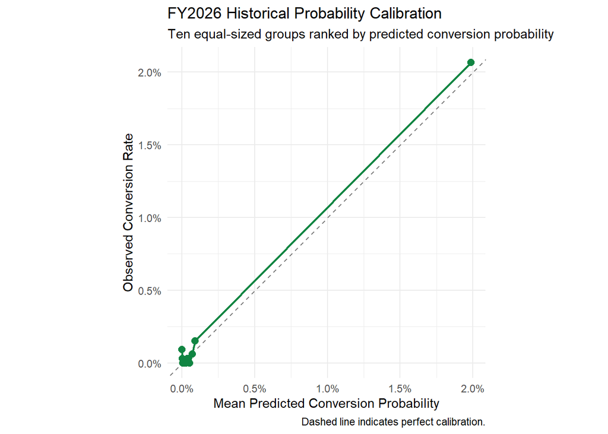

```r
calibration_by_group <- confirmation_predictions |>
  arrange(predicted_probability) |>
  mutate(risk_group = ntile(row_number(), 10L)) |>
  group_by(risk_group) |>
  summarise(
    n = n(),
    conversions = sum(observed_conversion),
    mean_predicted = mean(predicted_probability),
    observed_rate = mean(observed_conversion),
    .groups = "drop"
  )

calibration_by_group |>
  ggplot(aes(
    x = mean_predicted,
    y = observed_rate
  )) +
  geom_abline(
    intercept = 0,
    slope = 1,
    linetype = "dashed",
    color = "gray50"
  ) +
  geom_line(
    color = "#108542",
    linewidth = 0.8
  ) +
  geom_point(
    color = "#108542",
    size = 2.5
  ) +
  scale_x_continuous(
    labels = scales::label_percent(accuracy = 0.1)
  ) +
  scale_y_continuous(
    labels = scales::label_percent(accuracy = 0.1)
  ) +
  coord_equal() +
  labs(
    title = "FY2026 Historical Probability Calibration",
    subtitle = "Ten equal-sized groups ranked by predicted conversion probability",
    x = "Mean Predicted Conversion Probability",
    y = "Observed Conversion Rate",
    caption = "Dashed line indicates perfect calibration."
  ) +
  theme_minimal()
```

```r
# Optional outputs. The score file is restricted to the FY2025 eligible pool.
# readr::write_csv(comparison, here("Data_Files", "model_comparison.csv"))
# readr::write_csv(selected_settings, here("Data_Files", "selected_hyperparameters.csv"))
# readr::write_csv(confirmation_results, here("Data_Files", "confirmation_metrics.csv"))
# readr::write_csv(confirmation_predictions, here("Data_Files", "confirmation_scores.csv"))
```

The calibration plot compares predicted major-donor conversion probabilities with observed FY2026 conversion rates across ten approximately equal-sized groups of constituents. The dashed diagonal represents perfect calibration, where predicted probabilities equal observed conversion rates. Differences between the plotted points and this reference line indicate potential overestimation or underestimation of conversion probabilities.

Because major-donor conversions are relatively rare, some groups contain few observed conversions, making their estimated conversion rates sensitive to individual outcomes. The Brier score provides an additional measure of probability prediction error, while the comparison with a constant-probability baseline helps assess whether the selected model improves on a simple prediction based on the development conversion rate. These diagnostics should be interpreted as descriptive evidence of historical calibration rather than proof that predicted probabilities will remain accurate in future fiscal years.

### Feature Importance

#### Calculate Feature Importance

Permutation feature importance is used to identify which predictors contribute most to the selected model’s ability to rank prospective major donors. Importance is measured by the decrease in Average Precision when a predictor is randomly shuffled while all other predictors remain unchanged.

A larger decrease indicates greater reliance on that predictor for ranking performance. Importance values are calculated using the FY2026 historical confirmation population and averaged across 20 permutations per predictor. Because predictors may be correlated, permutation importance should be interpreted as model reliance rather than an independent or causal effect of each variable.

```r
# ============================================================
# Permutation Feature Importance
# ============================================================

set.seed(42)

# Final fitted Logistic Regression model
final_model <- final_evaluation$fit

# Prepared FY2026 confirmation data
importance_data <- final_baked$valid

# Identify predictor columns after preprocessing
predictor_names <- setdiff(
  names(importance_data),
  "major_donor_next_fy"
)

# Function to generate predicted conversion probabilities
predict_probabilities <- function(model, new_data) {

  if (selected_algorithm == "Elastic Net") {

    predictors <- setdiff(
      names(new_data),
      "major_donor_next_fy"
    )

    return(as.numeric(
      predict(
        model,
        newx = as.matrix(new_data[, predictors, drop = FALSE]),
        s = as.numeric(selected_params$penalty),
        type = "response"
      )
    ))
  }

  predict(
    model,
    new_data = new_data,
    type = "prob"
  )$.pred_yes
}

# Calculate original Average Precision
baseline_predictions <- predict_probabilities(
  final_model,
  importance_data
)

baseline_ap <- yardstick::average_precision_vec(
  truth = importance_data$major_donor_next_fy,
  estimate = baseline_predictions,
  event_level = "first"
)

# Number of permutations per predictor
n_repeats <- 20

# Calculate permutation importance
feature_importance <- purrr::map_dfr(
  predictor_names,
  function(feature) {

    permuted_ap <- replicate(n_repeats, {

      permuted_data <- importance_data

      # Randomly shuffle one predictor
      permuted_data[[feature]] <- sample(
        permuted_data[[feature]]
      )

      # Generate predictions using shuffled data
      predictions <- predict_probabilities(
        final_model,
        permuted_data
      )

      # Calculate Average Precision after permutation
      yardstick::average_precision_vec(
        truth = permuted_data$major_donor_next_fy,
        estimate = predictions,
        event_level = "first"
      )
    })

    tibble(
      Feature = feature,
      Baseline_AP = baseline_ap,
      Permuted_AP = mean(permuted_ap),
      Importance = baseline_ap - mean(permuted_ap),
      SD = sd(baseline_ap - permuted_ap)
    )
  }
) |>
  arrange(desc(Importance))

# Display feature importance table
feature_importance |>
  gt() |>
  tab_header(
    title = "Selected Model Feature Importance",
    subtitle = paste(
      selected_algorithm,
      "/",
      config_labels[[selected_configuration]]
    )
  ) |>
  fmt_number(
    columns = c(Baseline_AP, Permuted_AP, Importance, SD),
    decimals = 4
  ) |>
  cols_label(
    Feature = "Predictor",
    Baseline_AP = "Original AP",
    Permuted_AP = "Permuted AP",
    Importance = "AP Decrease",
    SD = "SD"
  )
```

Selected Model Feature Importance

Logistic Regression / Benchmark + Giving History

| Predictor | Original AP | Permuted AP | AP Decrease | SD |
| --- | --- | --- | --- | --- |
| average_recognized_per_active_year | 0.2862 | 0.0016 | 0.2846 | 0.0000 |
| log_current_giving | 0.2862 | 0.0040 | 0.2822 | 0.0005 |
| cumulative_soft_amount | 0.2862 | 0.0228 | 0.2634 | 0.0081 |
| active_giving_years | 0.2862 | 0.0240 | 0.2622 | 0.0073 |
| cumulative_recognized_amount | 0.2862 | 0.0261 | 0.2601 | 0.0049 |
| highest_giving_tier_to_date_Entry....120. | 0.2862 | 0.0826 | 0.2036 | 0.0251 |
| cumulative_gift_count | 0.2862 | 0.1129 | 0.1733 | 0.0145 |
| average_gifts_per_active_year | 0.2862 | 0.1185 | 0.1677 | 0.0228 |
| highest_giving_tier_to_date_Sustaining...120..599. | 0.2862 | 0.1228 | 0.1634 | 0.0258 |
| prior_giving_tier_Major...1.200.. | 0.2862 | 0.1491 | 0.1371 | 0.0056 |
| prior_giving_tier_Sustaining...120..599. | 0.2862 | 0.1917 | 0.0945 | 0.0246 |
| soft_amount | 0.2862 | 0.1958 | 0.0905 | 0.0031 |
| soft_credit_count | 0.2862 | 0.2040 | 0.0822 | 0.0144 |
| prior_giving_tier_Entry....120. | 0.2862 | 0.2074 | 0.0788 | 0.0396 |
| highest_giving_tier_to_date_Upper.mid...600..1.199. | 0.2862 | 0.2197 | 0.0665 | 0.0049 |
| log_peak_annual_giving | 0.2862 | 0.2338 | 0.0524 | 0.0175 |
| prior_giving_tier_Upper.mid...600..1.199. | 0.2862 | 0.2723 | 0.0139 | 0.0067 |
| any_soft_credit_to_date | 0.2862 | 0.2733 | 0.0129 | 0.0137 |
| cumulative_direct_amount | 0.2862 | 0.2829 | 0.0033 | 0.0089 |
| trailing_three_year_slope | 0.2862 | 0.2844 | 0.0018 | 0.0020 |
| direct_payment_count | 0.2862 | 0.2859 | 0.0003 | 0.0003 |
| peak_annual_giving_to_date | 0.2862 | 0.2862 | 0.0000 | 0.0000 |
| prior_giving_tier_unknown | 0.2862 | 0.2862 | 0.0000 | 0.0000 |
| highest_giving_tier_to_date_Major...1.200.. | 0.2862 | 0.2862 | 0.0000 | 0.0000 |
| prior_recognized_amount | 0.2862 | 0.2886 | −0.0024 | 0.0045 |
| yoy_change | 0.2862 | 0.2891 | −0.0029 | 0.0014 |
| cumulative_direct_payment_count | 0.2862 | 0.2898 | −0.0036 | 0.0148 |
| cumulative_soft_credit_count | 0.2862 | 0.2909 | −0.0046 | 0.0041 |
| direct_amount | 0.2862 | 0.2921 | −0.0059 | 0.0046 |

#### Feature Importance Visualization

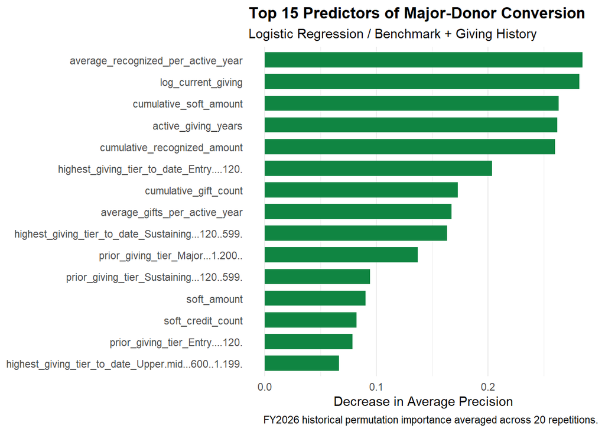

```r
# ============================================================
# Top 15 Most Important Predictors
# ============================================================

feature_importance |>
  slice_max(
    order_by = Importance,
    n = 15,
    with_ties = FALSE
  ) |>
  mutate(
    Feature = forcats::fct_reorder(
      Feature,
      Importance
    )
  ) |>
  ggplot(aes(
    x = Importance,
    y = Feature
  )) +
  geom_col(
    fill = "#108542",
    width = 0.7
  ) +
  labs(
    title = "Top 15 Predictors of Major-Donor Conversion",
    subtitle = paste(
      selected_algorithm,
      "/",
      config_labels[[selected_configuration]]
    ),
    x = "Decrease in Average Precision",
    y = NULL,
    caption = "FY2026 historical permutation importance averaged across 20 repetitions."
  ) +
  theme_minimal() +
  theme(
    plot.title = element_text(face = "bold"),
    panel.grid.major.y = element_blank()
  )
```

### Interpretation of Results

Permutation feature importance indicates that the selected Logistic Regression model relies heavily on constituents’ historical giving behavior to identify prospective major donors. The largest decreases in Average Precision occurred when average recognized giving per active year (0.2846), current-year giving (0.2822), cumulative soft-credit amount (0.2634), active giving years (0.2622), and cumulative recognized giving (0.2601) were permuted.

These findings suggest that giving intensity, recent contributions, and cumulative giving activity provide important information for distinguishing constituents who subsequently reach the major-donor threshold. However, several predictors measure related aspects of giving behavior, so their importance values should not be interpreted as independent contributions. Furthermore, permutation importance measures the model’s reliance on each predictor rather than the direction or causal effect of its association with conversion.

The selected model achieved a Brier score of 0.00200, compared with 0.00243 for the constant-probability baseline, representing a 17.69% reduction in prediction error. This indicates that the model provided more accurate probability predictions than assigning every constituent the same probability based on the development conversion rate.

The observed FY2026 conversion rate was 0.243%, compared with 0.148% in the development population. This difference highlights the potential for conversion rates to change between fiscal years and reinforces the importance of monitoring probability calibration over time. Although the model improved on the constant-probability baseline, the Brier score alone does not establish that predicted probabilities are well calibrated across all risk levels. The calibration plot provides additional information about agreement between predicted and observed conversion rates.

### Limitations

Several limitations should be considered when interpreting the modeling results and applying the selected model to fundraising decisions:

- **Limited Development History.** The available development data support only two chronological validation folds, restricting the ability to evaluate model performance across different fiscal-year conditions. Because major-donor conversions are relatively rare, performance estimates may also be sensitive to a small number of individual outcomes.
- **Model Selection Uncertainty.** Hyperparameter tuning and model selection were conducted using the same development folds. Although this provides a consistent comparison across algorithms and predictor configurations, the resulting development performance estimates may be optimistic. Small differences in Average Precision should not necessarily be interpreted as meaningful differences in future predictive performance.
- **Historical Evaluation.** The selected model was evaluated using FY2025 predictors and FY2026 outcomes. Although this provides evidence of predictive performance on a later fiscal year, results from a single evaluation period may not generalize to future years. Changes in donor behavior, fundraising practices, and conversion rates could affect subsequent model performance.
- **Restricted Prospect Population.** The model was developed using constituents with recognized giving greater than $0 and less than $1,200 in the feature fiscal year. Consequently, its predictions apply to existing donors within this giving range and should not be generalized to constituents with no current-year recognized giving or those already meeting the major-donor threshold.
- **Recognized Giving Versus Cash Revenue.** The outcome includes both positive direct payments and soft credits. Although soft credits contribute to recognized giving, they do not necessarily represent additional cash revenue attributable to the constituent. Reaching the modeled threshold should therefore not be interpreted as generating $1,200 in new cash contributions.
- **Predictive Rather Than Causal Relationships.** The model identifies associations between historical constituent characteristics and subsequent major-donor conversion. Feature importance does not establish that individual predictors cause increased giving, and strong ranking performance does not demonstrate that additional outreach would generate incremental donations.
- **Future Generalizability.** Changes in donor behavior, fundraising practices, data availability, and overall conversion rates may affect model performance in future fiscal years. The selected model should therefore be monitored and periodically reevaluated as new data become available.

These limitations support using the model as a decision-support tool alongside fundraising staff judgment rather than as a standalone basis for solicitation decisions.

## Conclusion

This analysis developed and evaluated a predictive modeling framework to help PBS Utah identify existing donors who are most likely to reach the $1,200 major-donor threshold in the following fiscal year. Five classification algorithms were compared across five predictor configurations using chronological development validation, with Average Precision serving as the primary model-selection metric.

**Logistic Regression with Benchmark + Giving History predictors was selected as the best-performing configuration during development.** When evaluated using FY2025 features and FY2026 outcomes, the model achieved an Average Precision of 0.2862, ROC AUC of 0.9245, and Brier score of 0.00200. The Brier score represented a 17.69% improvement over a constant-probability baseline, providing additional evidence of predictive value beyond ranking performance.

The model demonstrated particularly strong performance in identifying prospective major donors within relatively small prospect lists. Among 32,886 eligible constituents, 80 reached the major-donor threshold in FY2026. The top 100 ranked constituents contained 31 of these conversions (38.75%), while the top 250 contained 47 (58.75%) and the top 500 contained 56 (70.00%). At the top-500 cutoff, the model achieved a lift of 46.04 relative to random selection, demonstrating its ability to concentrate historical major-donor conversions within a small portion of the eligible population.

Permutation feature importance indicated that the model relied heavily on historical giving characteristics, particularly average recognized giving per active year, current-year giving, cumulative soft-credit amount, active giving years, and cumulative recognized giving. These findings suggest that existing giving records provide substantial predictive information for identifying constituents with higher estimated conversion potential.

From a business perspective, the selected model provides PBS Utah with a systematic approach to prioritizing existing donors for prospect research and cultivation. Rather than distributing limited fundraising resources equally across all eligible constituents, development staff could use model-generated rankings to focus attention on a smaller group with higher estimated probabilities of reaching the major-donor threshold.

However, the FY2026 evaluation represents historical confirmation rather than a prospective test, and the model identifies associations with future giving rather than the incremental impact of fundraising outreach. Its predictions should therefore support, rather than replace, staff judgment and established donor relationships.

Overall, the project establishes a reproducible, data-driven framework for identifying potential major donors and provides PBS Utah with a practical foundation for more targeted fundraising strategies.